# Week 5 Discussion - PCA

# Principal Component Analysis (Task)

The “cities30.csv” dataset includes the rating on 30 cities in 9 dimensions. 1. Climate and Terrain (the higher the score the better) 2. Housing (the lower the score the better) 3. Health Care & the Environment (the higher the score the better) 4. Crime (the lower the score the better) 5. Transportation (the higher the score the better) 6. Education (the higher the score the better) 7. The Arts (the higher the score the better) 8. Recreation (the higher the score the better) 9. Economics (the higher the score the better)

### 1. Examine the data

### 2. Show some basic descriptive info and discuss the data structure

```r
cities30 <- read.table("C:/Users/bae96639/Desktop/Uploads/cities30.csv",sep=",",header = T)

head(cities30)
```

```
##                  City Climate Housing HlthCare Crime Transp Educ  Arts Recreat
## 1 Anaheim-Santa-AnaCA     885   16047     2025   983   3954 2843  5632    3156
## 2           AtlantaGA     696    8316     3195  1308   8409 3057  7559    1362
## 3         BaltimoreMD     567    9148     3562  1730   7405 3471  9788    2925
## 4            BostonMA     623   11609     5301  1215   6801 3479 21042    3066
## 5           ChicagoIL     514   10913     5766  1034   7742 3486 24846    2856
## 6  CincinnatiOH-KY-IN     584    8143     2138   978   5748 2918  9688    2451
##   Econ     Pop
## 1 6220 1932709
## 2 6315 2138231
## 3 5503 2199531
## 4 6363 2805911
## 5 5205 6060387
## 6 5270 1401491
```

Since ‘City’ is our primary key, it won’t be considered one of the variables or ‘dimensions’ we’re exploring with PCA

All of the dimension observations are numeric, the only difference is that Pop is not a rating

I can already tell that I’ll need to scale the data

Basic EDA and reading in my libraries:

```r
library(FactoMineR)
library(factoextra)
names(cities30)
```

```
##  [1] "City"     "Climate"  "Housing"  "HlthCare" "Crime"    "Transp"
##  [7] "Educ"     "Arts"     "Recreat"  "Econ"     "Pop"
```

Quick overview of the average of each category:

```r
mean(cities30$Climate)
```

```
## [1] 633.2
```

```r
mean(cities30$Housing)
```

```
## [1] 10972.2
```

```r
mean(cities30$HlthCare)
```

```
## [1] 3384.733
```

```r
mean(cities30$Crime)
```

```
## [1] 1337.767
```

```r
mean(cities30$Transp)
```

```
## [1] 5931.6
```

```r
mean(cities30$Educ)
```

```
## [1] 3132.933
```

```r
mean(cities30$Arts)
```

```
## [1] 12640.3
```

```r
mean(cities30$Recreat)
```

```
## [1] 2761.7
```

```r
mean(cities30$Pop)
```

```
## [1] 2637847
```

Looking at range of values:

```r
range(cities30$Climate)
```

```
## [1] 293 910
```

```r
range(cities30$Housing)
```

```
## [1]  7442 17158
```

```r
range(cities30$HlthCare)
```

```
## [1] 1189 7850
```

```r
range(cities30$Crime)
```

```
## [1]  566 2498
```

```r
range(cities30$Transp)
```

```
## [1] 2119 8625
```

```r
range(cities30$Educ)
```

```
## [1] 2596 3781
```

```r
range(cities30$Arts)
```

```
## [1]  4573 56745
```

```r
range(cities30$Recreat)
```

```
## [1] 1362 4800
```

```r
range(cities30$Pop)
```

```
## [1] 1295071 8274961
```

The difference in range for each:

```r
diff(range(cities30$Climate))
```

```
## [1] 617
```

```r
diff(range(cities30$Housing))
```

```
## [1] 9716
```

```r
diff(range(cities30$HlthCare))
```

```
## [1] 6661
```

```r
diff(range(cities30$Crime))
```

```
## [1] 1932
```

```r
diff(range(cities30$Transp))
```

```
## [1] 6506
```

```r
diff(range(cities30$Educ))
```

```
## [1] 1185
```

```r
diff(range(cities30$Arts))
```

```
## [1] 52172
```

```r
diff(range(cities30$Recreat))
```

```
## [1] 3438
```

```r
diff(range(cities30$Pop))
```

```
## [1] 6979890
```

Before manipulating my data or doing PCA, it seems the Arts have the greatest variance across my observations

Now I’ll clean my data before doing PCA:

```r
#check for NA values
sum(is.na(cities30))
```

```
## [1] 0
```

```r
#remove the primary key and population variable, store this df in a new object
cities_PCA <- cities30[-c(1,11)]
head(cities_PCA)
```

```
##   Climate Housing HlthCare Crime Transp Educ  Arts Recreat Econ
## 1     885   16047     2025   983   3954 2843  5632    3156 6220
## 2     696    8316     3195  1308   8409 3057  7559    1362 6315
## 3     567    9148     3562  1730   7405 3471  9788    2925 5503
## 4     623   11609     5301  1215   6801 3479 21042    3066 6363
## 5     514   10913     5766  1034   7742 3486 24846    2856 5205
## 6     584    8143     2138   978   5748 2918  9688    2451 5270
```

```r
#scale my data
cities_PCA <-as.data.frame(scale(cities_PCA))
head(cities_PCA)
```

```
##       Climate     Housing   HlthCare       Crime     Transp       Educ
## 1  1.57836513  1.84354398 -0.9553178 -0.81025685 -1.1820228 -0.9269399
## 2  0.39365103 -0.96492897 -0.1333023 -0.06798453  1.4807561 -0.2427649
## 3 -0.41496335 -0.66268482  0.1245435  0.89582753  0.8806596  1.0808260
## 4 -0.06393695  0.23133302  1.3463256 -0.28038861  0.5196453  1.1064026
## 5 -0.74718476 -0.02150583  1.6730240 -0.69377720  1.0820864  1.1287822
## 6 -0.30840177 -1.02777541 -0.8759266 -0.82167643 -0.1097388 -0.6871589
##         Arts    Recreat       Econ
## 1 -0.7003294  0.4454160  0.3220068
## 2 -0.5077670 -1.5811533  0.4277592
## 3 -0.2850262  0.1844698 -0.4761455
## 4  0.8395698  0.3437486  0.4811920
## 5  1.2196981  0.1065248 -0.8078741
## 6 -0.2950191 -0.3509783 -0.7355172
```

### 3. Conduct PCA using the above 9 variables

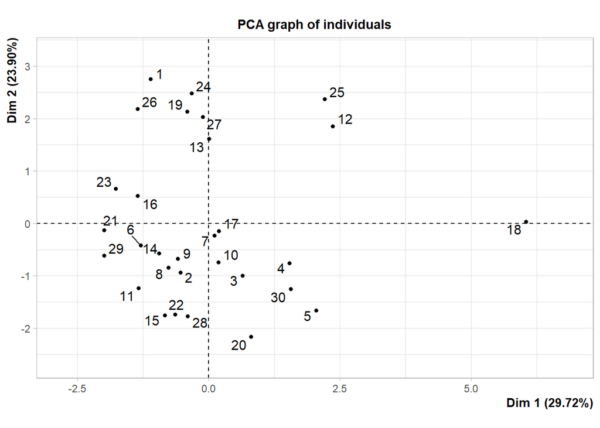

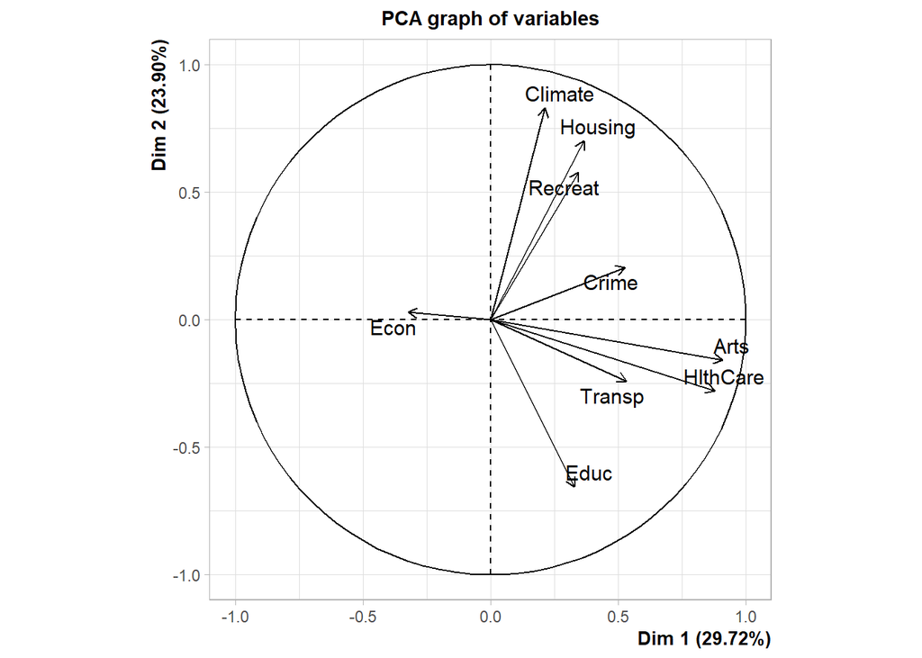

```r
c.pca <- PCA(cities_PCA,  graph = TRUE) #removed scale & column removal portions of code from practice, already completed
```

```r
print(c.pca)
```

```
## **Results for the Principal Component Analysis (PCA)**
## The analysis was performed on 30 individuals, described by 9 variables
## *The results are available in the following objects:
##
##    name               description
## 1  "$eig"             "eigenvalues"
## 2  "$var"             "results for the variables"
## 3  "$var$coord"       "coord. for the variables"
## 4  "$var$cor"         "correlations variables - dimensions"
## 5  "$var$cos2"        "cos2 for the variables"
## 6  "$var$contrib"     "contributions of the variables"
## 7  "$ind"             "results for the individuals"
## 8  "$ind$coord"       "coord. for the individuals"
## 9  "$ind$cos2"        "cos2 for the individuals"
## 10 "$ind$contrib"     "contributions of the individuals"
## 11 "$call"            "summary statistics"
## 12 "$call$centre"     "mean of the variables"
## 13 "$call$ecart.type" "standard error of the variables"
## 14 "$call$row.w"      "weights for the individuals"
## 15 "$call$col.w"      "weights for the variables"
```

```r
eig.val <- get_eigenvalue(c.pca)
eig.val
```

```
##       eigenvalue variance.percent cumulative.variance.percent
## Dim.1 2.67474678       29.7194087                    29.71941
## Dim.2 2.15113497       23.9014997                    53.62091
## Dim.3 1.11906827       12.4340919                    66.05500
## Dim.4 0.96928314       10.7698127                    76.82481
## Dim.5 0.72550534        8.0611704                    84.88598
## Dim.6 0.66815639        7.4239599                    92.30994
## Dim.7 0.43170487        4.7967208                    97.10666
## Dim.8 0.20364202        2.2626891                    99.36935
## Dim.9 0.05675822        0.6306469                   100.00000
```

The first four dimensions account for 76.82% of variance in the data, with the first two dimensions holding over half of the variance in the data

### 4. Interpret the results including the components, eigenvalues, quality of representation (cos2), the resulted map(s)

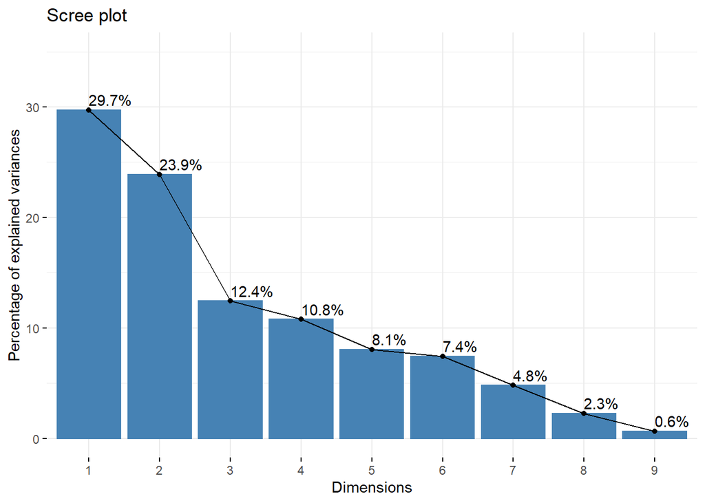

```r
fviz_eig(c.pca, addlabels = TRUE, ylim = c(0, 35))
```

The bar plot shows a more dramatic visual of how much more the first two dimensions account for variance in the data than the next dimensions 3 and 4

In Dim 1, Healthcare and Arts hold the highest influence while in Dim 2, Climate and Housing hold the highest influence

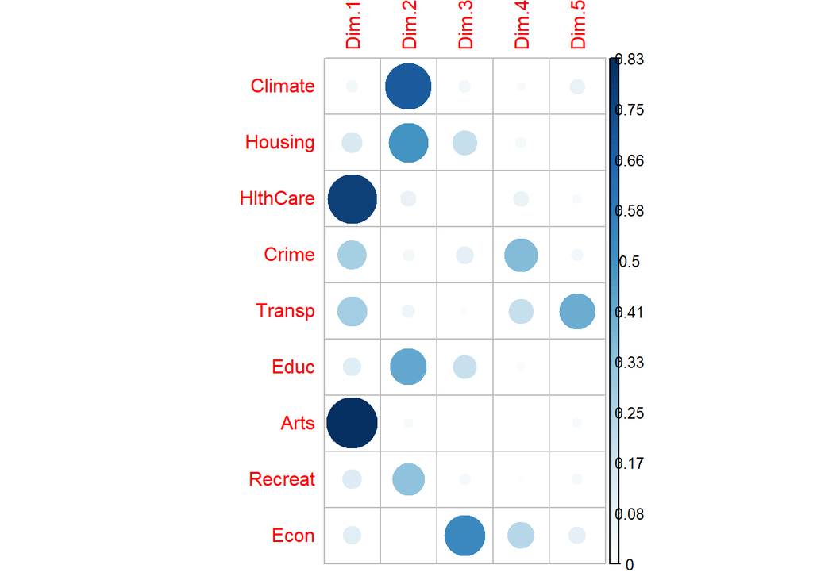

```r
library(corrplot)
var <- get_pca_var(c.pca)
corrplot(var$cos2, is.corr=FALSE)
```

This simple correlation matrix also supplements my previous findings

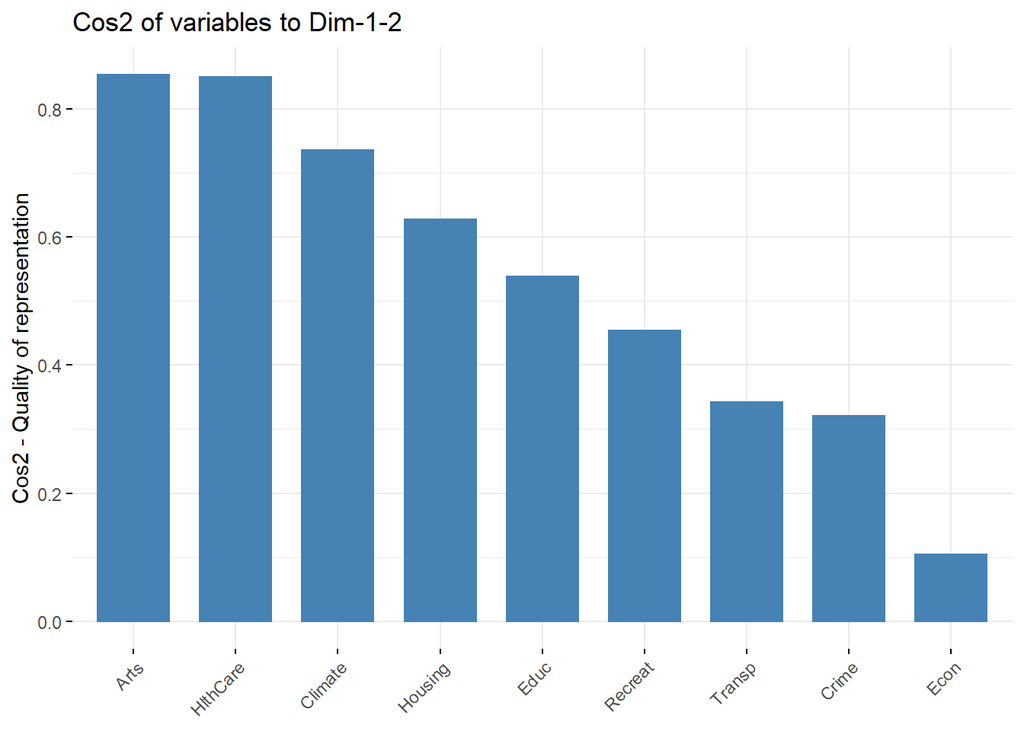

```r
fviz_cos2(c.pca, choice = "var", axes = 1:2)
```

The Cos2 gives us a better visual as to which variables we’re looking at that influence our data, rather than their variance in terms of “dimensions”

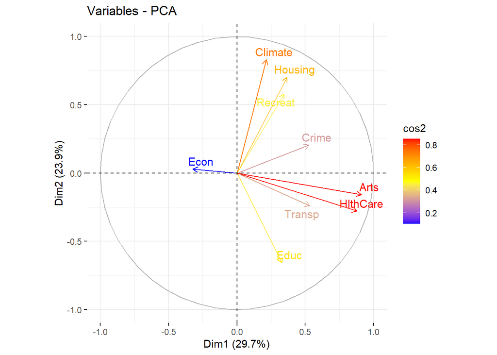

```r
fviz_pca_var(c.pca, col.var = "cos2",
             gradient.cols = c("blue", "yellow", "red"),
             repel = TRUE)
```

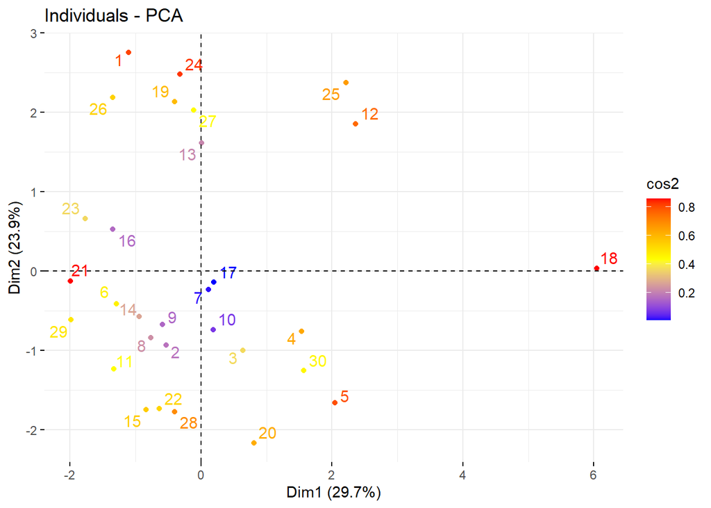

```r
fviz_pca_ind(c.pca, col.ind = "cos2",
             gradient.cols = c("blue", "yellow", "red"),
             repel= TRUE)
```

### 5. Check individual cities’ proximity on the map(s) (you can use “rownames(cities30) <- cities30 [, 1] to indicate the row names, which will help to build the map with names)

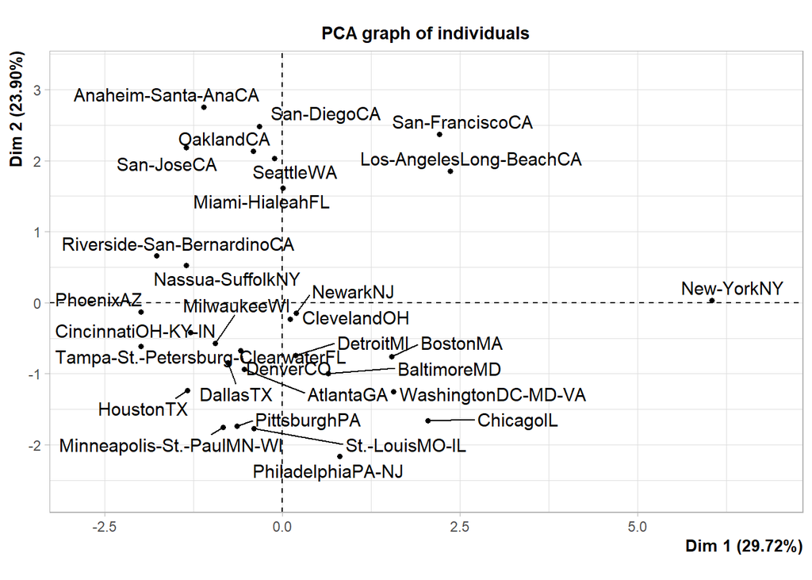

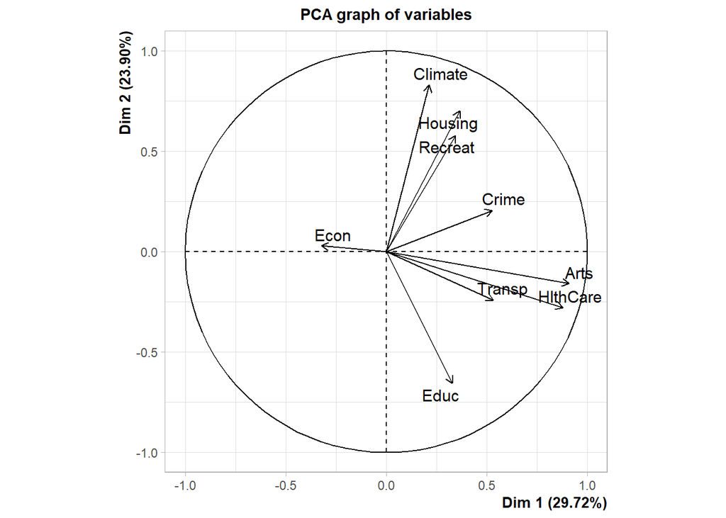

```r
rownames(cities30) <- cities30 [, 1]
names.pca <- PCA(cities30[,2:10], scale.unit = TRUE,  graph = TRUE)
```

Enhanced PCA map of city names:

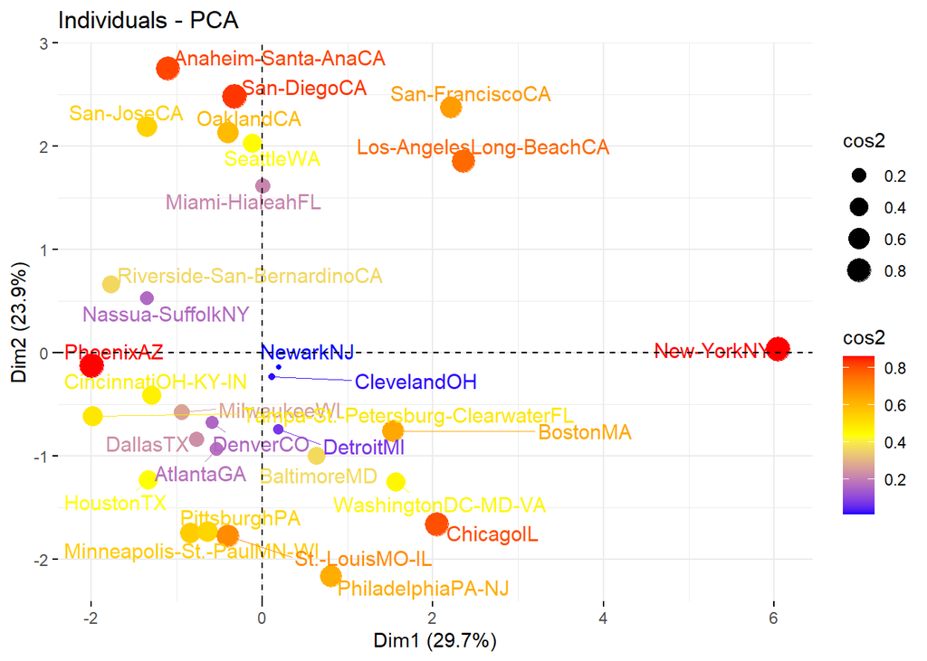

```r
fviz_pca_ind(names.pca, col.ind = "cos2", pointsize = "cos2",
             gradient.cols = c("blue", "yellow", "red"),
             repel = TRUE)
```

### 6. Check the map containing both individual cities and variables

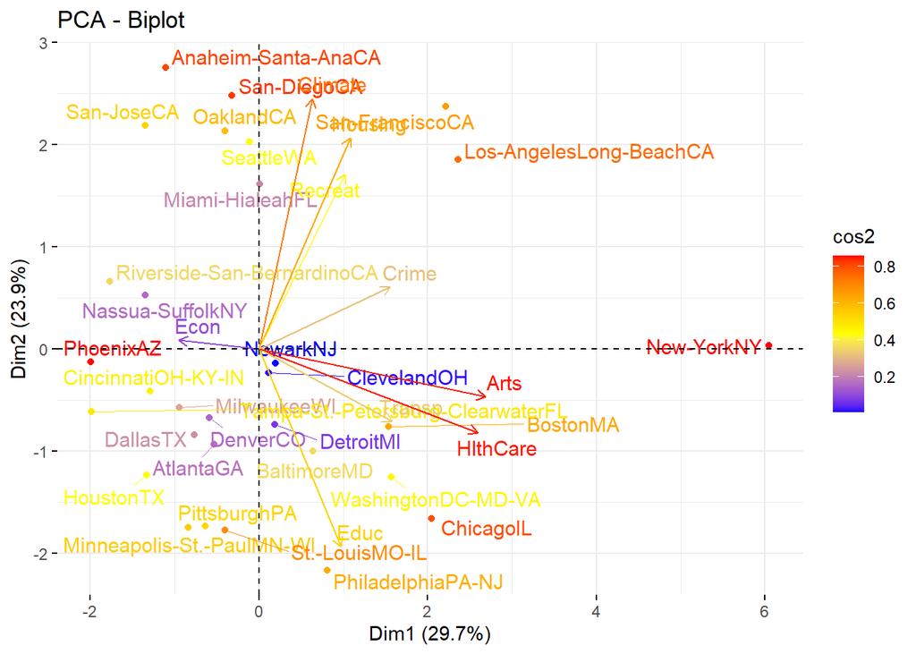

```r
fviz_pca_biplot(names.pca, col.var = "cos2", col.ind = "cos2",
                gradient.cols = c("blue", "yellow", "red"),
                axes = 1:2,
                repel = TRUE)
```

### 7. Use the “pop” (population) as the supplementary variable and predict its position on the map

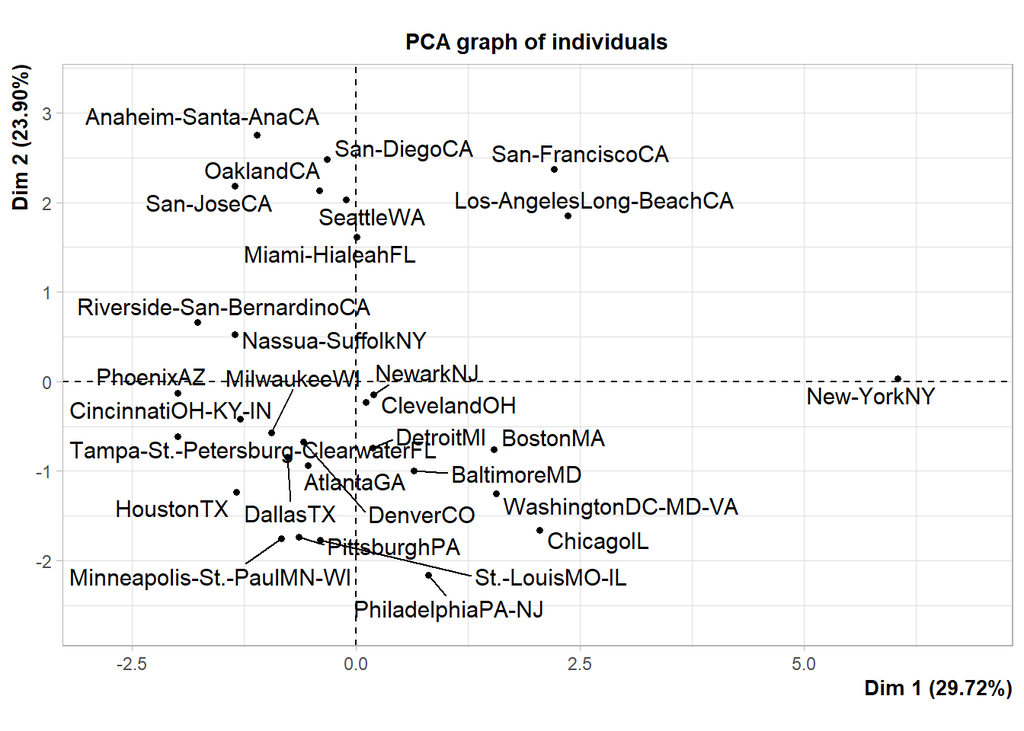

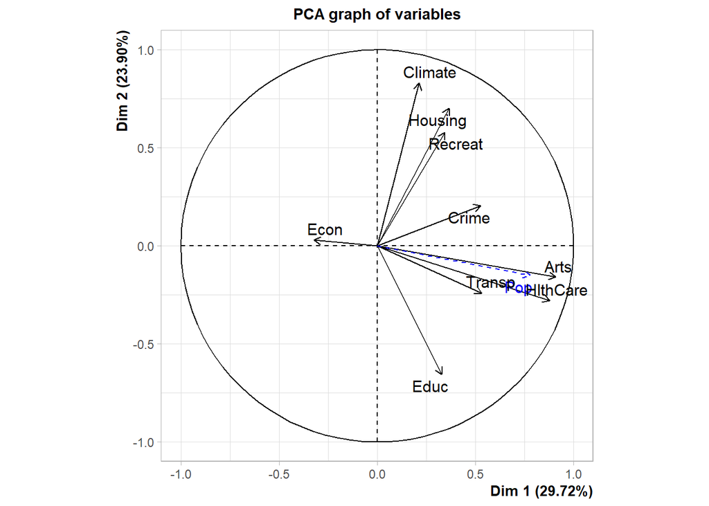

```r
pop.pca <- PCA(cities30[, 2:11], scale.unit = TRUE, quanti.sup = 10,  graph= TRUE)
```